# Logistic Regression

Author

Andreas Blombach, Philipp Heinrich

Published

July 31, 2024

```r
library(tidyverse)
library(broom)
library(skimr)
library(scales) # percent
library(moderndive) # geom_parallel_slopes
library(car)
library(ggcorrplot)
library(rms)
library(caret)
library(yardstick)
```

## A simple classification problem

Can Germans correctly pronounce ‘squirrel’ if their shoes are on fire? Let’s have a look at some (entirely made-up) experimental data to find out!

We’ll include two predictor variables:

- language proficiency (0-5, see https://en.wikipedia.org/wiki/ILR_scale)
- shoes on fire (yes, no)

```r
data <- tibble(
  Pronunciation = factor(c(0, 0, 0, 0,
                           0, 0, 0, 1, 0, 0, 1,
                           1, 0, 0, 0, 1, 0, 0, 1, 0,
                           0, 1, 1, 0, 1, 0, 0, 0, 1, 1, 0, 1, 0, 1, 1,
                           1, 1, 0, 1, 0, 1, 1, 1, 0, 1, 1,
                           1, 1, 1, 1,
                           0, 0, 0,
                           0, 0, 0, 0, 0, 0, 0, 0, 0,
                           0, 1, 0, 0, 0, 0, 0, 0, 0,
                           1, 0, 0, 1, 0, 1, 0, 0, 0, 0, 0,
                           1, 1, 0, 0, 1, 0, 1, 1, 0, 0, 0, 1, 0,
                           1, 0, 1, 1, 1),
                         labels = c("Wrong", "Correct")),
  Proficiency = c(rep(0, 4), rep(1, 7), rep(2, 9), rep(3, 15), rep(4, 11), rep(5, 4),
                  rep(0, 3), rep(1, 9), rep(2, 9), rep(3, 11), rep(4, 13), rep(5, 5)),
  Shoes_on_fire = factor(c(rep(0, 50), rep(1, 50)), labels = c("No", "Yes"))
)
skim(data)
```

Data summary

| Name | data |
| --- | --- |
| Number of rows | 100 |
| Number of columns | 3 |
| _______________________ |  |
| Column type frequency: |  |
| factor | 2 |
| numeric | 1 |
| ________________________ |  |
| Group variables | None |

**Variable type: factor**

| skim_variable | n_missing | complete_rate | ordered | n_unique | top_counts |
| --- | --- | --- | --- | --- | --- |
| Pronunciation | 0 | 1 | FALSE | 2 | Wro: 61, Cor: 39 |
| Shoes_on_fire | 0 | 1 | FALSE | 2 | No: 50, Yes: 50 |

**Variable type: numeric**

| skim_variable | n_missing | complete_rate | mean | sd | p0 | p25 | p50 | p75 | p100 | hist |
| --- | --- | --- | --- | --- | --- | --- | --- | --- | --- | --- |
| Proficiency | 0 | 1 | 2.71 | 1.41 | 0 | 2 | 3 | 4 | 5 | ▇▆▇▇▃ |

Let’s start by visually inspecting the relationship between `Pronunciation` and the two independent variables:

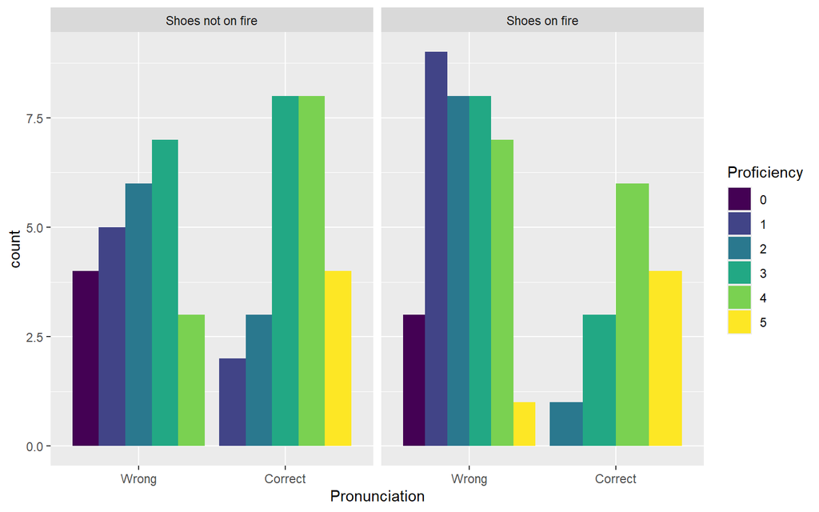

```r
# new labels for facets:
shoe_labs = as_labeller(c(No = "Shoes not on fire", Yes = "Shoes on fire"))


data |> ggplot(aes(x = Pronunciation, fill = factor(Proficiency))) +
  geom_bar(position = "dodge") +
  facet_wrap(~ Shoes_on_fire, labeller = shoe_labs) +
  scale_fill_viridis_d() +
  labs(fill = "Proficiency")
```

We can also create a scatter plot, but since our dependent variable is categorical, we wouldn’t be able to see much without adding some random noise to each observation’s position.

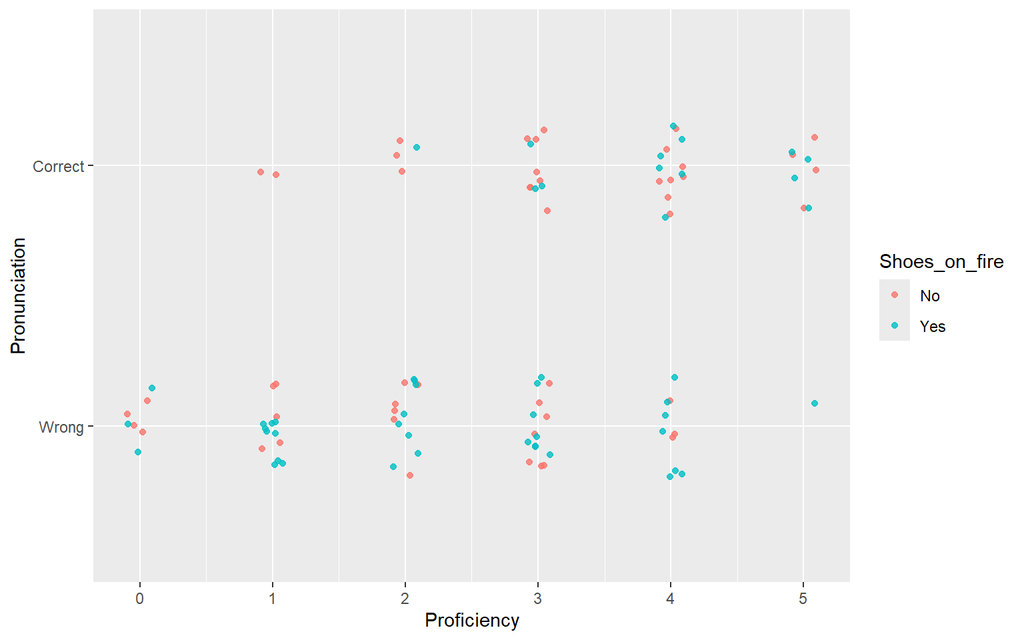

```r
data |> ggplot(aes(x = Proficiency, y = Pronunciation, colour = Shoes_on_fire)) +
  geom_jitter(width = .1, height = .2, alpha = .8)
```

Another possibility is to count the number of observations at a given point in the coordinate system and to map it to point area.

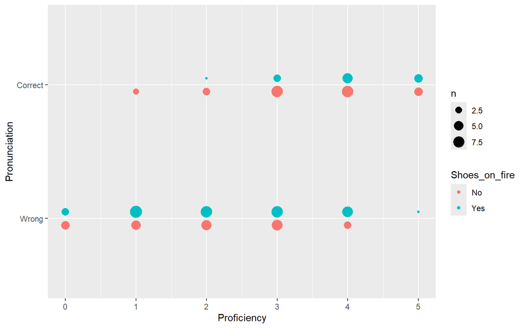

```r
data |> ggplot(aes(x = Proficiency, y = Pronunciation, group = Shoes_on_fire, colour = Shoes_on_fire)) +
  geom_count(position = position_dodge(width = .2))
```

## Linear regression

If we try linear regression with a categorical outcome, R will throw disgusted warning messages at us and refuse to speak to us for the next hour or so. We also won’t be able to do much with the output. So let’s not do that.

As linear regression requires a numeric outcome, we could, however, just convert the levels of the categorical dependent variable to numbers. In our case, these numbers would be 1 for the correct pronunciation and 0 for the wrong pronunciation.

```r
linmod <- lm(as.integer(Pronunciation) - 1 ~ Shoes_on_fire + Proficiency,
             data = data) # correct: 1, wrong: 0
summary(linmod)
```

```
Call:
lm(formula = as.integer(Pronunciation) - 1 ~ Shoes_on_fire +
    Proficiency, data = data)

Residuals:
     Min       1Q   Median       3Q      Max
-0.72598 -0.32451  0.01788  0.33310  0.84668

Coefficients:
                 Estimate Std. Error t value Pr(>|t|)
(Intercept)       0.04119    0.09903   0.416  0.67834
Shoes_on_fireYes -0.23027    0.08330  -2.764  0.00683 **
Proficiency       0.17120    0.02971   5.763 9.78e-08 ***
---
Signif. codes:  0 '***' 0.001 '**' 0.01 '*' 0.05 '.' 0.1 ' ' 1

Residual standard error: 0.4164 on 97 degrees of freedom
Multiple R-squared:  0.2929,    Adjusted R-squared:  0.2784
F-statistic: 20.09 on 2 and 97 DF,  p-value: 4.996e-08
```

We can actually visualise our predictions using the plot above as a base. Since we have not included an interaction between `Shoes_on_fire` and `Proficiency`, the slopes are parallel to each other:

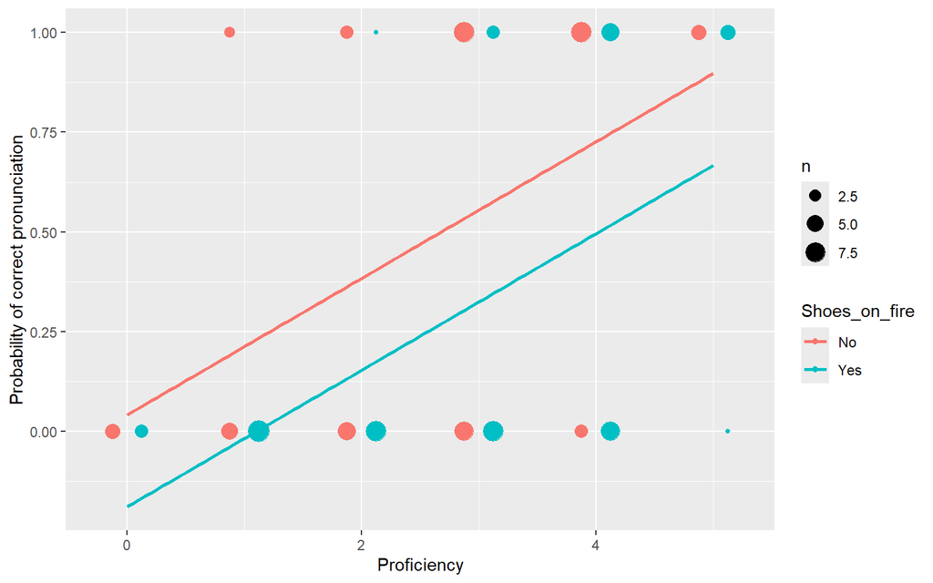

```r
data |> mutate(Pronunciation = as.integer(Pronunciation) - 1) |>
  ggplot(aes(x = Proficiency, y = Pronunciation, group = Shoes_on_fire, colour = Shoes_on_fire)) +
  geom_count(position = position_dodge(width = .5)) +
  geom_parallel_slopes(se = FALSE) + # moderndive
  labs(y = "Probability of correct pronunciation")
```

At first glance, the model doesn’t look too bad. Both predictors appear to be significant, and the values make some sense: If a participant’s shoes are on fire, the predicted outcome will be lower by .23, so a wrong pronunciation is more likely in this case. And a higher language proficiency increases the predicted outcome (.17 for each proficiency point).

The whole model has an adjusted R² value of .28 which, while not spectacular, is not too bad.

However, some predicted probabilities don’t make much sense at all – they are negative!

```r
augment(linmod) |> arrange(.fitted)
```

| as.integer(Pronunciation) - 1 | Shoes_on_fire | Proficiency | .fitted | .resid | .hat | .sigma | .cooksd | .std.resid |
| --- | --- | --- | --- | --- | --- | --- | --- | --- |
| 0 | Yes | 0 | -0.18907684 | 0.18907684 | 0.05820662 | 0.4181184 | 4.509592e-03 | 0.4678654 |
| 0 | Yes | 0 | -0.18907684 | 0.18907684 | 0.05820662 | 0.4181184 | 4.509592e-03 | 0.4678654 |
| 0 | Yes | 0 | -0.18907684 | 0.18907684 | 0.05820662 | 0.4181184 | 4.509592e-03 | 0.4678654 |
| 0 | Yes | 1 | -0.01788092 | 0.01788092 | 0.03540763 | 0.4185869 | 2.338774e-05 | 0.0437198 |
| 0 | Yes | 1 | -0.01788092 | 0.01788092 | 0.03540763 | 0.4185869 | 2.338774e-05 | 0.0437198 |
| 0 | Yes | 1 | -0.01788092 | 0.01788092 | 0.03540763 | 0.4185869 | 2.338774e-05 | 0.0437198 |
| 0 | Yes | 1 | -0.01788092 | 0.01788092 | 0.03540763 | 0.4185869 | 2.338774e-05 | 0.0437198 |
| 0 | Yes | 1 | -0.01788092 | 0.01788092 | 0.03540763 | 0.4185869 | 2.338774e-05 | 0.0437198 |
| 0 | Yes | 1 | -0.01788092 | 0.01788092 | 0.03540763 | 0.4185869 | 2.338774e-05 | 0.0437198 |
| 0 | Yes | 1 | -0.01788092 | 0.01788092 | 0.03540763 | 0.4185869 | 2.338774e-05 | 0.0437198 |

[output cut: 90 more lines]

Likewise, it is also possible to predict probabilities greater than 1 using a linear model. Since we don’t want that, let’s turn to our lord and saviour, logistic regression.

## Logistic Regression

Logistic regression is an extension of linear regression and a special case of the so-called generalised linear model (GLM/GLiM).

In linear regression, the relationship between dependent variable and a number of independent variables could be modelled as follows:

$$y_i = \beta_0 + \beta_1 x_{1i} + \beta_2 x_{2i} + \ldots + \beta_n x_{ni} + \varepsilon_i$$

In logistic regression, the values of the dependent variable are no longer predicted directly. Instead, we predict the probability of one level given the values of the independent variables. (This probability is also called *probability of success*.)

Again, this level is internally represented as 1; for a factor in R, the second level is chosen – so if you want to change that, you have to change the order of the levels.

The formula thus becomes:

$$P(y_i = 1) = \frac{1}{1 + e^{-(\beta_0 + \beta_1 x_{1i} + \beta_2 x_{2i} + \ldots + \beta_n x_{ni})}}$$
The formula may be easier to understand if we split it up. One part is the linear predictor which we might (should!) remember from (multiple) linear regression:

$$t = \beta_0 + \beta_1 x_{1i} + \beta_2 x_{2i} + \ldots + \beta_n x_{ni}$$
The other part is the logistic function (a sigmoid function) that converts any real number (the input) into a value between 0 and 1 (output). This function thus takes on the role of the *link function* – a link function (often non-linear) is an integral part of every generalised linear model.

It looks like this:

$$f(t) = \frac{1}{1 + e^{-t}} = \frac{e^{t}}{1 + e^{t}}$$

In R (try different input values!):

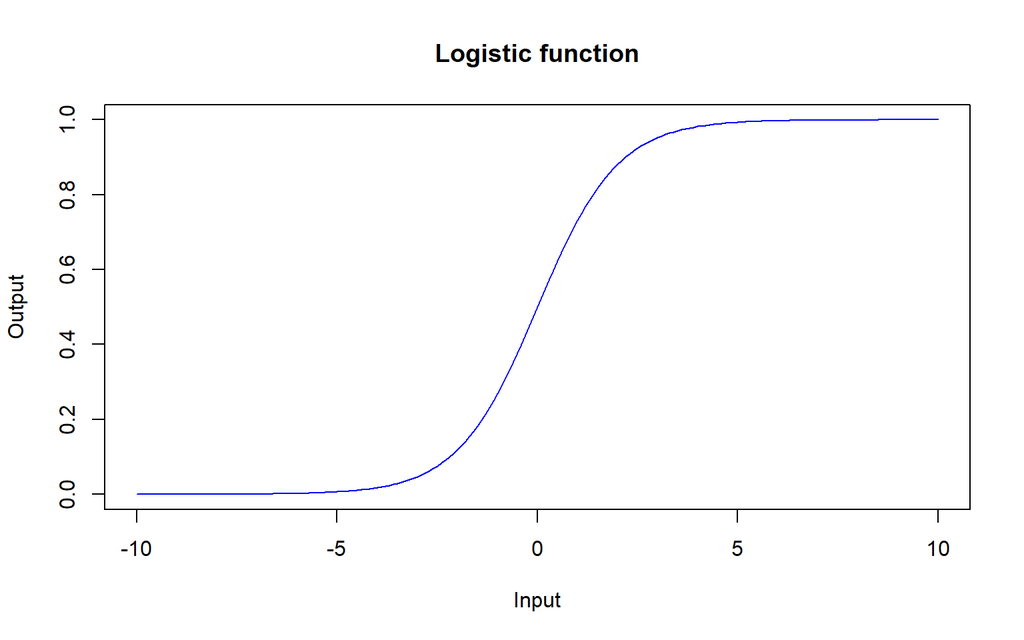

```r
logistic <- function(x) {
  output <- 1 / (1 + exp(-x))
  return(output)
}
x <- seq(-10, 10, .1)
plot(x, logistic(x), type = "l",
     col = "blue",
     main = "Logistic function",
     ylab = "Output",
     xlab = "Input")
```

Looking closely at the curve, you may realise that an equally large change in the input can lead to different changes in the output, depending on the initial value of the input.

For example, if $x$ is 0 and then increases by 0.4, y increases from 0.5 to ~0.6 (if interpreted as probabilities, i.e. from 50% to ~60%). If, on the other hand, x is first 3.2, then also increases by 0.4, y increases from ~0.96 to only ~0.97.

This will become very important when interpreting the coefficients of a logistic regression model. (It will also be frustrating. Sorry!)

Instead of `logistic()` we can also use `plogis()`. The logistic function is often called $logit^{-1}(t)$, because it is the inverse function of the logit function, which maps the values from 0 to 1 (usually probabilities) to -∞ to +∞ (R function: `qlogis()`):

$$logit(p) = ln(\frac{p}{1 - p})$$
$$\frac{p}{1 - p}$$
are the *odds*, a measure of the likelihood of a particular outcome given by the probability of an event divided by the probability of its complement (the probability of the event not occurring). Consequently, the logit function is the (natural) logarithm of the odds (and therefore also called *log-odds*).

(A logit value of 0 corresponds to a probability of 0.5; furthermore, positive logit values correspond to probabilities > 0.5 and negative values to probabilities < 0.5).

So, we can also write the formula for logistic regression as:

$$P(y_i = 1) = p_i = logit^{-1}(t)$$
$$logit(p_i) = \beta_0 + \beta_1 x_{1i} + \beta_2 x_{2i} + \ldots + \beta_n x_{ni}$$
This relationship is linear. But in contrast to linear regression, we cannot use the method of least squares to calculate parameter values. Instead, they must be estimated via *maximum likelihood*. A maximum likelihood estimation (*MLE*) selects those parameter values that make the occurrence of the observed values appear most likely (by maximising the *likelihood function*).

To create a logistic regression model in R, we use `glm()`. Since this function is used for different generalised linear models, we also need to specify `family = binomial`.

```r
logmod <- glm(Pronunciation ~ Proficiency + Shoes_on_fire,
              family = binomial, data = data)
logmod
```

```
Call:  glm(formula = Pronunciation ~ Proficiency + Shoes_on_fire, family = binomial,
    data = data)

Coefficients:
     (Intercept)       Proficiency  Shoes_on_fireYes
          -2.801             1.027            -1.381

Degrees of Freedom: 99 Total (i.e. Null);  97 Residual
Null Deviance:      133.7
Residual Deviance: 99.06    AIC: 105.1
```

Let’s compare curves:

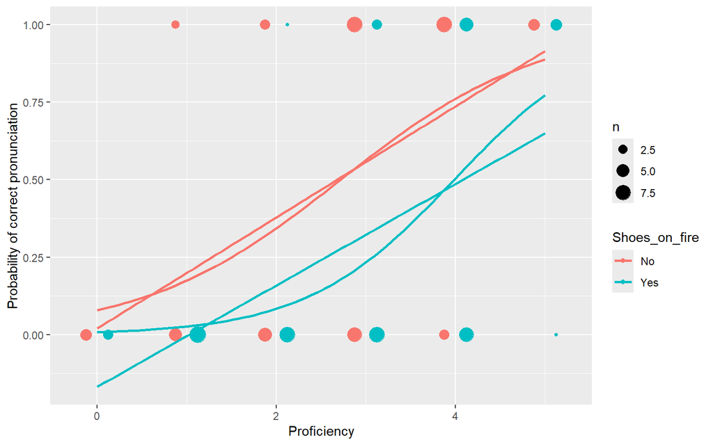

```r
# includes interaction(!)
data |> mutate(Pronunciation = as.integer(Pronunciation) - 1) |>
  ggplot(aes(x = Proficiency, y = Pronunciation, group = Shoes_on_fire, colour = Shoes_on_fire)) +
  geom_count(position = position_dodge(width = .5)) +
  geom_smooth(method = glm, se = FALSE, method.args = list(family = binomial)) +
  geom_smooth(method = lm, se = FALSE) +
  labs(y = "Probability of correct pronunciation")
```

Without interaction (actual model predictions):

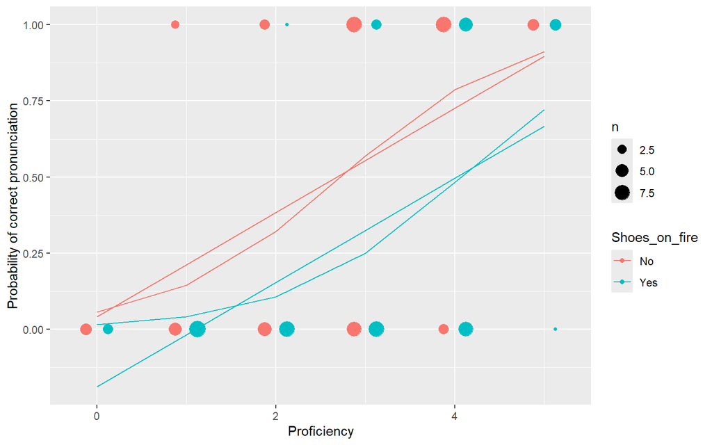

```r
plin <- augment(linmod)
plog <- augment(logmod, type.predict = "response")

data |> mutate(Pronunciation = as.integer(Pronunciation) - 1) |>
  ggplot(aes(x = Proficiency, y = Pronunciation, group = Shoes_on_fire, colour = Shoes_on_fire)) +
  geom_count(position = position_dodge(width = .5)) +
  geom_line(aes(y = .fitted), data = plin) +
  geom_line(aes(y = .fitted), data = plog) +
  labs(y = "Probability of correct pronunciation")
```

We can see that our logistic regression model doesn’t predict negative probabilities. Yay! But how good is the model?

Let’s go through the output.

```r
summary(logmod)
```

```
Call:
glm(formula = Pronunciation ~ Proficiency + Shoes_on_fire, family = binomial,
    data = data)

Coefficients:
                 Estimate Std. Error z value Pr(>|z|)
(Intercept)       -2.8006     0.7322  -3.825 0.000131 ***
Proficiency        1.0275     0.2333   4.404 1.06e-05 ***
Shoes_on_fireYes  -1.3810     0.5195  -2.658 0.007851 **
---
Signif. codes:  0 '***' 0.001 '**' 0.01 '*' 0.05 '.' 0.1 ' ' 1

(Dispersion parameter for binomial family taken to be 1)

    Null deviance: 133.750  on 99  degrees of freedom
Residual deviance:  99.062  on 97  degrees of freedom
AIC: 105.06

Number of Fisher Scoring iterations: 5
```

Sadly, interpreting the coefficients isn’t as straightforward as with linear regression.

The coefficient of `Proficiency` tells us the following: If `Proficiency` is increased by 1 (holding other variables, i.e. `Shoes_on_fire`, constant), the logit (the logarithm of the odds, log-odds) increases by ~1.03.

What?

```r
tidy(logmod)
```

| term | estimate | std.error | statistic | p.value |
| --- | --- | --- | --- | --- |
| (Intercept) | -2.800613 | 0.7322371 | -3.824735 | 1.309127e-04 |
| Proficiency | 1.027482 | 0.2332818 | 4.404466 | 1.060446e-05 |
| Shoes_on_fireYes | -1.380956 | 0.5194627 | -2.658432 | 7.850527e-03 |

Looking at the signs of the estimates, we see that higher values of `Proficiency` increase the logit and thus the probability of the correct pronunciation. Likewise, burning shoes (`Yes`) decrease it (compared to the reference level, `No`).

As mentioned above, using the logit results in a linear relationship, although we can’t really interpret it:

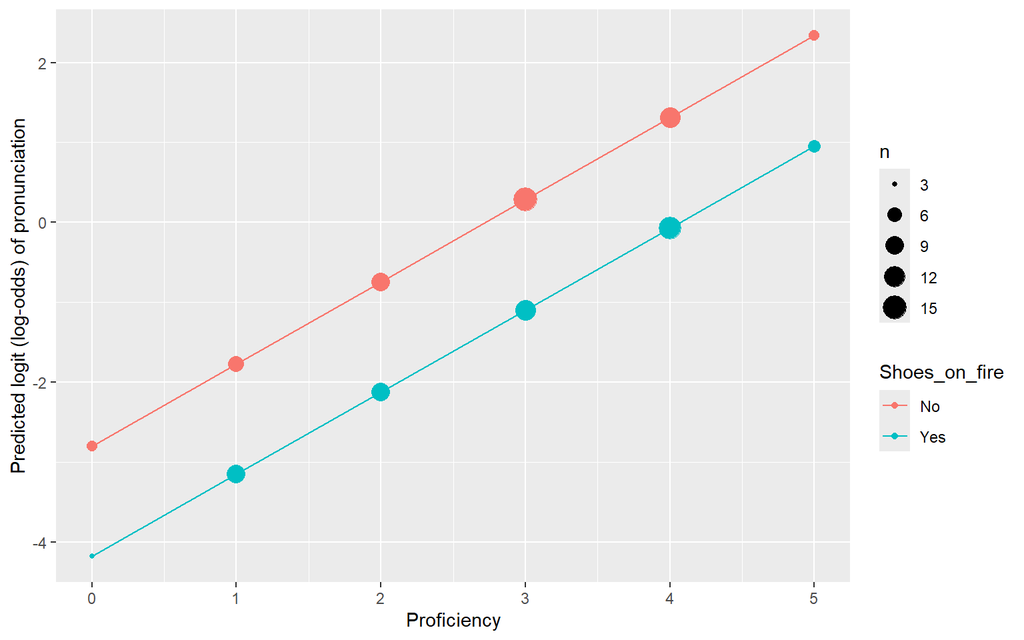

```r
plog <- plog |> mutate(logit = log(.fitted / (1 - .fitted))) # or: augment(logmod, type.predict = "link")
plog |>
  ggplot(aes(x = Proficiency, y = logit, colour = Shoes_on_fire)) +
  geom_count() +
  geom_line() +
  labs(y = "Predicted logit (log-odds) of pronunciation")
```

The inverse function of the natural logarithm is the exponential function $e^x$. It is often applied to the coefficients (in R: `exp()`). The transformed coefficients are to be interpreted differently: If the variable in question is increased by one unit, the odds are multiplied by the transformed value. So, if you prefer to think in terms of odds instead of log-odds, this may at least be *slightly* more intuitive.

```r
exp(coef(logmod))
```

```
     (Intercept)      Proficiency Shoes_on_fireYes
       0.0607728        2.7940214        0.2513381
```

```r
exp(confint(logmod)) # confidence intervals
```

```
                      2.5 %    97.5 %
(Intercept)      0.01245472 0.2263874
Proficiency      1.83983730 4.6354264
Shoes_on_fireYes 0.08610214 0.6710984
```

Annoyingly, the coefficients cannot be related directly to the probabilities because the relationship between the probability of success and the linear predictor is not linear (as can be seen above, looking at the curve of the logistic function). A one-unit increase in an independent variable can therefore lead to different changes in the probability of success, depending on its initial value.

```r
glance(logmod)
```

| null.deviance | df.null | logLik | AIC | BIC | deviance | df.residual | nobs |
| --- | --- | --- | --- | --- | --- | --- | --- |
| 133.7496 | 99 | -49.53081 | 105.0616 | 112.8771 | 99.06163 | 97 | 100 |

We still need some statistics to assess goodness of fit. In the output, we already see the *deviance*:

$$Deviance = -2 \cdot LL$$

*LL* stands for log-likelihood. In principle, this is analogous to the residual sum of squares: It shows us how much unexplained information remains after fitting the model.

The log-likelihood is computed using the observed (O) values and those predicted by the model (P = probability of success).

$$LL = \sum \limits_{i=1}^{N} (O_i \ln(P_i) + (1 - O_i) \ln(1 - P_i))$$

```r
observed <- data$Pronunciation |> as.integer() - 1
predicted <- predict(logmod, type = "response")
LL <- sum(observed * log(predicted) + (1 - observed) * log(1 - predicted))
LL
```

```
[1] -49.53081
```

To get the deviance, we multiply this value by -2, so it is $\chi^2$-distributed – we can then compute a *p*-value. The smaller the deviance, the better.

```r
-2 * LL
```

```
[1] 99.06163
```

For a statistical test of the whole model, one can calculate the deviance difference between the base or null model (model with $\beta_0$ only) and the full model; the degrees of freedom also result from the difference of the respective degrees of freedom (and each model has as many degrees of freedom as observations minus parameters).

```r
x2 <- logmod$null.deviance - logmod$deviance
df <- logmod$df.null - logmod$df.residual
pchisq(x2, df, lower.tail = FALSE)
```

```
[1] 2.934935e-08
```

This is a likelihood-ratio test showing us that the model as a whole is significant.

We’re still missing something like $R^2$, telling us how well the model fits the data.

Because we’re not the only ones missing this, many *pseudo*-$R^2$ variants have been developed for logistic regression. Unfortunately, which of these is most suitable is disputed.

Hosmer and Lemeshow (1989) proposed to divide the likelihood ratio, i.e. the deviance difference we have just calculated, by the deviance of the null model:

```r
x2 / logmod$null.deviance
```

```
[1] 0.2593502
```

The function `lrm()` from the `rms` package gives us Nagelkerke’s R²:

```r
lrm(Pronunciation ~ Proficiency + Shoes_on_fire,
    data = data)
```

```
Logistic Regression Model

lrm(formula = Pronunciation ~ Proficiency + Shoes_on_fire, data = data)

                       Model Likelihood     Discrimination    Rank Discrim.
                             Ratio Test            Indexes          Indexes
Obs           100    LR chi2      34.69     R2       0.397    C       0.819
 Wrong         61    d.f.             2     R2(2,100)0.279    Dxy     0.639
 Correct       39    Pr(> chi2) <0.0001    R2(2,71.4)0.367    gamma   0.693
max |deriv| 5e-10                           Brier    0.167    tau-a   0.307

                  Coef    S.E.   Wald Z Pr(>|Z|)
Intercept         -2.8006 0.7322 -3.82  0.0001
Proficiency        1.0275 0.2333  4.40  <0.0001
Shoes_on_fire=Yes -1.3810 0.5195 -2.66  0.0079
```

## A more complicated classification problem

Remember our SMS data set? Let’s see if we can use logistic regression to predict if a message is ham or spam.

Cleaning up the texts might help a bit:

```r
# smsspam <- read_tsv(
#   "../data/smsspam.tsv",
#   quote = "",
#   col_names = c("y", "text")
# )
#
# weird <- substr(smsspam$text[19], 13, 13)
# smsspam$text <- str_replace_all(smsspam$text, weird, "'")
# smsspam$text <- str_replace_all(smsspam$text, "\u0094", '"')
# smsspam$text <- str_replace_all(smsspam$text, "\u0091", "'")
# smsspam$text <- str_replace_all(smsspam$text, "\u0096", "\u2013")
# smsspam$text <- str_replace_all(smsspam$text, "\u0093", "")
# smsspam$text <- str_replace_all(smsspam$text, "&lt;", "<")
# smsspam$text <- str_replace_all(smsspam$text, "&gt;", ">")
# smsspam$text <- str_replace_all(smsspam$text, "&amp;", "&")
#
# smsspam$text <- str_replace_all(smsspam$text, r"([[:digit:]]{5,}|\b[0-9]{3,}([[:space:],–-]?[0-9]{2,})+\b)", "<#>")
#
# write.table(smsspam, "../data/smsspam_clean.tsv", quote = FALSE,
#             sep = "\t", fileEncoding = "UTF-8", row.names = FALSE)

smsspam <- read_tsv(
  "../data/smsspam_clean.tsv",
  quote = ""
)

smsspam <- distinct(smsspam)
```

Let’s craft some features. Keep in mind that `spam_words` and `ham_words` include manually selected words – that’s *not* the way to go, we’re just doing this to demonstrate the distinctive power of relevant words.

```r
smsspam$y |> table() |> prop.table() # majority classifier: "ham" (87,8%)
```

```
      ham      spam
0.8781341 0.1218659
```

```r
re_spam <- regex(r"(\b(urgent|txt|cash|mobile|claim|chance|w[io]n|prize|msg|nokia|horny|admirer|xxx)\b|free|http|www|\.(com|net|co\.uk|org)|[$£]|\bsex|[0-9]{3,})",
                 ignore_case = TRUE)

re_ham <- regex(r"(\b(love|miss|hope|home|haha|lol|yeah|than(ks|x)|thx|sleep|sorry|gonna|much|well|morning|come|like|my|u|ü|ur|class|wan|(be)?co[sz]|i'm|hi|wait)\b|'ll)",
                ignore_case = TRUE)

spam <- smsspam |>
  mutate(y = factor(y),
         length = str_length(text),
         punct = str_count(text, "[[:punct:]]") / length,
         numbers = str_detect(text, "<#>"),
         spam_words = str_count(text, re_spam),
         ham_words = str_count(text, re_ham))

spam |>
  group_by(y) |>
  summarise(mean_length = mean(length),
            sd_length = sd(length),
            mean_punct = mean(punct),
            sd_punct = sd(punct),
            pct_numbers = sum(numbers) / n(),
            mean_spam_words = mean(spam_words),
            sd_spam_words = sd(spam_words),
            mean_ham_words = mean(ham_words),
            sd_ham_words = sd(ham_words))
```

| y | mean_length | sd_length | mean_punct | sd_punct | pct_numbers | mean_spam_words | sd_spam_words | mean_ham_words | sd_ham_words |
| --- | --- | --- | --- | --- | --- | --- | --- | --- | --- |
| ham | 70.42342 | 55.94488 | 0.05736451 | 0.05409282 | 0.04426737 | 0.07038513 | 0.3133858 | 1.043603 | 1.3663149 |
| spam | 131.65710 | 29.39897 | 0.04998645 | 0.02575968 | 0.78309410 | 3.35885167 | 2.3544731 | 0.569378 | 0.8680816 |

How well do `length`, `numbers` and `punct` work together?

```r
spammod <- glm(y ~ length + numbers + punct,
               family = binomial,
               data = spam)
summary(spammod)
```

```
Call:
glm(formula = y ~ length + numbers + punct, family = binomial,
    data = spam)

Coefficients:
              Estimate Std. Error z value Pr(>|z|)
(Intercept) -4.0357266  0.1684415 -23.959  < 2e-16 ***
length       0.0101408  0.0009855  10.290  < 2e-16 ***
numbersTRUE  4.1000765  0.1278914  32.059  < 2e-16 ***
punct       -6.4694718  1.9687446  -3.286  0.00102 **
---
Signif. codes:  0 '***' 0.001 '**' 0.01 '*' 0.05 '.' 0.1 ' ' 1

(Dispersion parameter for binomial family taken to be 1)

    Null deviance: 3813.7  on 5144  degrees of freedom
Residual deviance: 1910.0  on 5141  degrees of freedom
AIC: 1918

Number of Fisher Scoring iterations: 6
```

Let’s now include our crude hand-crafted features `ham_words` and `spam_words` as additional predictors:

```r
spammod <- glm(y ~ length + numbers + spam_words + ham_words + punct,
               family = binomial,
               data = spam)
summary(spammod)
```

```
Call:
glm(formula = y ~ length + numbers + spam_words + ham_words +
    punct, family = binomial, data = spam)

Coefficients:
              Estimate Std. Error z value Pr(>|z|)
(Intercept)  -4.202146   0.224577 -18.711  < 2e-16 ***
length        0.006245   0.001397   4.470 7.83e-06 ***
numbersTRUE   3.154571   0.201914  15.623  < 2e-16 ***
spam_words    2.378722   0.128999  18.440  < 2e-16 ***
ham_words    -0.719501   0.107833  -6.672 2.52e-11 ***
punct       -10.382202   3.191278  -3.253  0.00114 **
---
Signif. codes:  0 '***' 0.001 '**' 0.01 '*' 0.05 '.' 0.1 ' ' 1

(Dispersion parameter for binomial family taken to be 1)

    Null deviance: 3813.74  on 5144  degrees of freedom
Residual deviance:  895.08  on 5139  degrees of freedom
AIC: 907.08

Number of Fisher Scoring iterations: 8
```

This doesn’t look too bad. We can also have a look at the predicted labels and compare them to the real ones:

```r
spam_prob <- predict(spammod, type = "response")
cats.pred <- factor(ifelse(spam_prob > .5, "spam", "ham"))
sum(cats.pred == spam$y) / nrow(spam) # accuracy
```

```
[1] 0.9724004
```

If we don’t just want to know how many labels were predicted correctly all in all, we can also look at the *confusion matrix* to see how many times *each label* was predicted correctly and how many times it was wrongly predicted as another label. The matrix thus shows the model’s confusion (not your own, although you may also be confused at first) – instances in which one label is confused for another.

The rows of the confusion matrix are the predicted labels, the columns are the true labels:

```r
table(cats.pred, spam$y)
```

```
cats.pred  ham spam
     ham  4482  106
     spam   36  521
```

We can also use `confusionMatrix()` from the `caret` package to get the confusion matrix and additional statistics:

```r
confusionMatrix(cats.pred, spam$y)
```

```
Confusion Matrix and Statistics

          Reference
Prediction  ham spam
      ham  4482  106
      spam   36  521

               Accuracy : 0.9724
                 95% CI : (0.9675, 0.9767)
    No Information Rate : 0.8781
    P-Value [Acc > NIR] : < 2.2e-16

                  Kappa : 0.8645

 Mcnemar's Test P-Value : 7.024e-09

            Sensitivity : 0.9920
            Specificity : 0.8309
         Pos Pred Value : 0.9769
         Neg Pred Value : 0.9354
             Prevalence : 0.8781
         Detection Rate : 0.8711
   Detection Prevalence : 0.8917
      Balanced Accuracy : 0.9115

       'Positive' Class : ham
```

[This Wikipedia page](https://en.wikipedia.org/wiki/Evaluation_of_binary_classifiers) is a very useful reference. :)

[`yardstick`’s function reference](https://yardstick.tidymodels.org/reference/index.html) may also be helpful.

Using the `yardstick` package from the newer `tidymodels` framework instead:

```r
cm <- tibble(truth = spam$y, pred = cats.pred) |>
  conf_mat(truth, pred)
cm
```

```
          Truth
Prediction  ham spam
      ham  4482  106
      spam   36  521
```

Same summary statistics, just as a tibble:

```r
cm |> summary()
```

| .metric | .estimator | .estimate |
| --- | --- | --- |
| accuracy | binary | 0.9724004 |
| kap | binary | 0.8645350 |
| sens | binary | 0.9920319 |
| spec | binary | 0.8309410 |
| ppv | binary | 0.9768963 |
| npv | binary | 0.9353680 |
| mcc | binary | 0.8664691 |
| j_index | binary | 0.8229729 |
| bal_accuracy | binary | 0.9114864 |
| detection_prevalence | binary | 0.8917396 |

[output cut: 3 more lines]

These observations have been falsely classified:

```r
spam |> filter(cats.pred != spam$y) |> arrange(y)
```

| y | text | length | punct | numbers | spam_words | ham_words |
| --- | --- | --- | --- | --- | --- | --- |
| ham | Turns out my friends are staying for the whole show and won't be back til ~ , so feel free to go ahead and smoke that $ worth | 134 | 0.029850746 | TRUE | 3 | 1 |
| ham | I'm going for bath will msg you next min.. | 48 | 0.083333333 | TRUE | 1 | 1 |
| ham | I wnt to buy a BMW car urgently..its vry urgent.but hv a shortage of Lacs.there is no source to arng dis amt. lacs..thats my prob | 138 | 0.065217391 | TRUE | 1 | 1 |
| ham | It doesnt make sense to take it there unless its free. If you need to know more, wikipedia.com | 94 | 0.031914894 | FALSE | 2 | 0 |
| ham | Sir, I have been late in paying rent for the past few months and had to pay a $ charge. I felt it would be inconsiderate of me to nag about something you give at great cost to yourself and that's why … | 366 | 0.021857923 | TRUE | 1 | 3 |
| ham | Meanwhile in the shit suite: xavier decided to give us seconds of warning that samantha was coming over and is playing jay's guitar to impress her or some shit. Also I don't think doug realizes I don'… | 225 | 0.026666667 | TRUE | 0 | 0 |
| ham | 1) Go to write msg 2) Put on Dictionary mode 3)Cover the screen with hand, 4)Press . 5)Gently remove Ur hand.. Its interesting..:) | 135 | 0.103703704 | TRUE | 1 | 1 |
| ham | You have registered Sinco as Payee. Log in at icicibank.com and enter URN to confirm. Beware of frauds. Do NOT share or disclose URN to anyone. | 149 | 0.040268456 | TRUE | 1 | 0 |
| ham | How to Make a girl Happy? It's not at all difficult to make girls happy. U only need to be... 1. A friend 2. Companion 3. Lover 4. Chef . . . . Good listener . Organizer . Good boyfriend . Very clean … | 503 | 0.121272366 | TRUE | 0 | 1 |
| ham | I was wondering if it would be okay for you to call uncle john and let him know that things are not the same in nigeria as they r here. That dollars is 2years sent and that you know its a strain but i… | 332 | 0.015060241 | TRUE | 0 | 1 |

[output cut: 132 more lines]

### Multicollinearity

While there is a strong correlation between `spam_words` and `numbers`, it’s not so high as to be problematic.

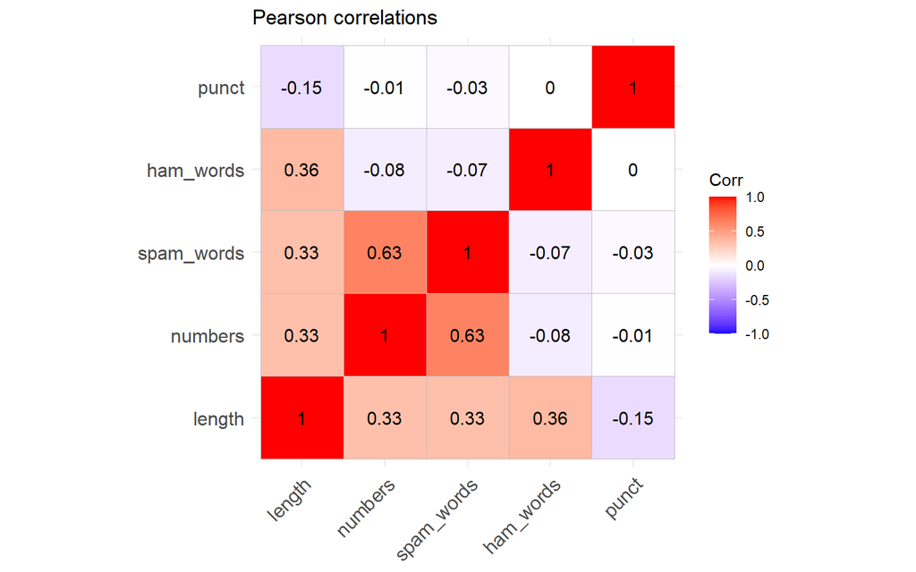

```r
spam |> select(length, numbers, spam_words, ham_words, punct) |>
  cor() |> ggcorrplot(lab = TRUE) +
  ggtitle("Pearson correlations")
```

Indeed, all variance inflation factors are close to 1; so is their mean.

```r
vif(spammod)
```

```
     length numbersTRUE  spam_words   ham_words       punct
   1.223985    1.112318    1.108306    1.208123    1.059882
```

```r
mean(vif(spammod))
```

```
[1] 1.142523
```